# Documentação e Análise dos Resultados

# Introdução

Esta é a documentação oficial do projeto, com as perguntas de negócio, as linhas de código explicadas e comentadas, e as respostas que obtivemos com as nossas análises.

Faremos uma análise financeira de dados hospitalares utilizando linguagem R, SQL e Regressão Linear.

## Fontes de dados

https://www.cms.gov/Research-Statistics-Data-and-Systems/Statistics-Trends-and-Reports/Medicare-Provider-Cost-Report/HospitalCostPUF

https://healthdata.gov/

Os dados são resultados de uma pesquisa nacional de custos hospitalares realizada pela US Agency for Healthcare que consiste em registros hospitalares de amostras de pacientes internados. Os dados são da cidade de Wisconsin e referem-se a pacientes na faixa etária de 0 a 17 anos.

## Objetivos do projeto

Uma rede de hospitais gostaria de compreender as variáveis relacionadas aos gastos com internações hospitalares de pacientes.

O projeto é composto de duas etapas. Primeiramente vamos explorar os dados usando Linguagem SQL através da linguagem R para responder 10 perguntas de negócio. Depois, vamos realizar análise estatística com Linguagem R através do Teste ANOVA e Regressão Linear, e responder 7 perguntas de negócio.

# Código explicado e comentado

Importando os pacotes necessários e lendo os dados do arquivo

```r
library(dplyr)
library(sqldf)
library(ggplot2)

dados = read.csv("dataset.csv")
```

Renomeando as variáveis

```r
nome_colunas = c("Idade", "Sexo", "TempoInternaçao", "Raça", "CustoInternaçao", "GrupoDiagnosticoRefinado")
names(dados) = nome_colunas
```

Checando valores missing

```r
sum(is.na(dados))
```

```
## [1] 1
```

```r
dim(dados)
```

```
## [1] 500   6
```

Excluindo a única linha que contem um valor missing

```r
dados = na.omit(dados)
dim(dados)
```

```
## [1] 499   6
```

Checando os tipos de dados

```r
str(dados)
```

```
## 'data.frame':    499 obs. of  6 variables:
##  $ Idade                   : int  17 17 17 17 17 17 17 16 16 17 ...
##  $ Sexo                    : int  1 0 1 1 1 0 1 1 1 1 ...
##  $ TempoInternaçao         : int  2 2 7 1 1 0 4 2 1 2 ...
##  $ Raça                    : int  1 1 1 1 1 1 1 1 1 1 ...
##  $ CustoInternaçao         : int  2660 1689 20060 736 1194 3305 2205 1167 532 1363 ...
##  $ GrupoDiagnosticoRefinado: int  560 753 930 758 754 347 754 754 753 758 ...
##  - attr(*, "na.action")= 'omit' Named int 277
##   ..- attr(*, "names")= chr "277"
```

Transformando as variáveis Sexo e Raça para fator

```r
unique(dados$Sexo)
```

```
## [1] 1 0
```

```r
dados$Sexo = as.factor(dados$Sexo)

unique(dados$Raça)
```

```
## [1] 1 4 6 2 5 3
```

```r
dados$Raça = as.factor(dados$Raça)
```

## Análise exploratória com linguagem SQL, para responder as perguntas de negócio

### Pergunta 1: Quantas raças estão representadas no dataset?

```r
sqldf("select Raça, count(Raça) as NumeroRaças from dados group by Raça")
```

```
##   Raça NumeroRaças
## 1    1         484
## 2    2           6
## 3    3           1
## 4    4           3
## 5    5           3
## 6    6           2
```

Existem 6 raças no dataset

### Pergunta 2: Qual a idade média dos pacientes?

```r
sqldf("select avg(Idade) from dados")
```

```
##   avg(Idade)
## 1   5.096192
```

A média de idade é de 5 anos

### Pergunta 3: Qual a moda da idade dos pacientes?

```r
sqldf("select Idade, count(*) as Contagem from dados group by Idade order by Contagem desc limit 1")
```

```
##   Idade Contagem
## 1     0      306
```

A idade que mais aparece é 0, com 306 registros

### Pergunta 4: Qual a variância da coluna idade?

```r
sqldf("select variance(Idade) as Variancia from dados")
```

```
##   Variancia
## 1  48.34013
```

A variância da idade é 48,34

### Pergunta 5: Qual o gasto total com internações hospitalares por idade?

```r
sqldf("select Idade, sum(CustoInternaçao) as Custo from dados group by Idade")
```

```
##    Idade  Custo
## 1      0 676962
## 2      1  37744
## 3      2   7298
## 4      3  30550
## 5      4  15992
## 6      5  18507
## 7      6  17928
## 8      7  10087
## 9      8   4741
## 10     9  21147
## 11    10  24469
## 12    11  14250
## 13    12  54912
## 14    13  31135
## 15    14  64643
## 16    15 111747
## 17    16  69149
## 18    17 174777
```

### Pergunta 6: Qual idade gera o maior gasto total com internações hospitalares?

```r
sqldf("select Idade, max(Custo) as Custo from (select Idade, sum(CustoInternaçao) as Custo from dados group by Idade)")
```

```
##   Idade  Custo
## 1     0 676962
```

A idade que mais gera gasto total é a idade 0

### Pergunta 7: Qual o gasto total com internações hospitalares por gênero?

```r
sqldf("select Sexo, sum(CustoInternaçao) as Custo from dados group by Sexo")
```

```
##   Sexo  Custo
## 1    0 735391
## 2    1 650647
```

O sexo masculino gera mais gastos do que o feminino

### Pergunta 8: Qual a média de gasto com internações hospitalares por raça do paciente?

```r
sqldf("select Raça, avg(CustoInternaçao) as MediaCusto from dados group by Raça")
```

```
##   Raça MediaCusto
## 1    1   2772.669
## 2    2   4202.167
## 3    3   3041.000
## 4    4   2344.667
## 5    5   2026.667
## 6    6   1349.000
```

### Pergunta 9: Para pacientes acima de 10 anos, qual a média de gasto total com internações hospitalares?

```r
sqldf("select Idade, avg(CustoInternaçao) as MediaCusto from dados where Idade > 10 group by Idade")
```

```
##   Idade MediaCusto
## 1    11   1781.250
## 2    12   3660.800
## 3    13   1729.722
## 4    14   2585.720
## 5    15   3853.345
## 6    16   2384.448
## 7    17   4599.395
```

A média de gasto com internações para pacientes acima de 10 anos é 3.213,66

### Pergunta 10: Considerando o item anterior, qual idade tem média de gastos superior a 3000?

```r
sqldf("Select Idade, avg(CustoInternaçao) as MediaCusto from dados where Idade > 10 group by Idade having MediaCusto > 3000")
```

```
##   Idade MediaCusto
## 1    12   3660.800
## 2    15   3853.345
## 3    17   4599.395
```

## Análise estatística com teste anova e regressão linear

### Pergunta 1: Qual a distribuição da idade dos pacientes que frequentam o hospital?

Podemos checar a distribuição pelo sumário de uma variável do tipo fator, e construir um histograma.

```r
summary(as.factor(dados$Idade))
```

```
##   0   1   2   3   4   5   6   7   8   9  10  11  12  13  14  15  16  17
## 306  10   1   3   2   2   2   3   2   2   4   8  15  18  25  29  29  38
```

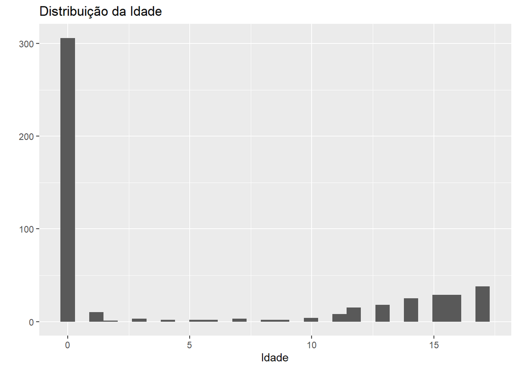

```r
ggplot(dados, aes(x = Idade)) +
  geom_histogram() +
  labs(title = "Distribuição da Idade") +
  ylab(label = "")
```

### Pergunta 2: Qual faixa etária tem o maior gasto total no hospital?

Podemos obter a informação que queremos através da funcão aggregate, e constuir um gráfico de barras.

```r
gasto_total_faixa_etaria = aggregate(data = dados,
                                     CustoInternaçao ~ Idade,
                                     FUN = sum)
gasto_total_faixa_etaria
```

```
##    Idade CustoInternaçao
## 1      0          676962
## 2      1           37744
## 3      2            7298
## 4      3           30550
## 5      4           15992
## 6      5           18507
## 7      6           17928
## 8      7           10087
## 9      8            4741
## 10     9           21147
## 11    10           24469
## 12    11           14250
## 13    12           54912
## 14    13           31135
## 15    14           64643
## 16    15          111747
## 17    16           69149
## 18    17          174777
```

```r
which.max(tapply(gasto_total_faixa_etaria$CustoInternaçao,
                 gasto_total_faixa_etaria$CustoInternaçao,
                 FUN = sum))
```

```
## 676962
##     18
```

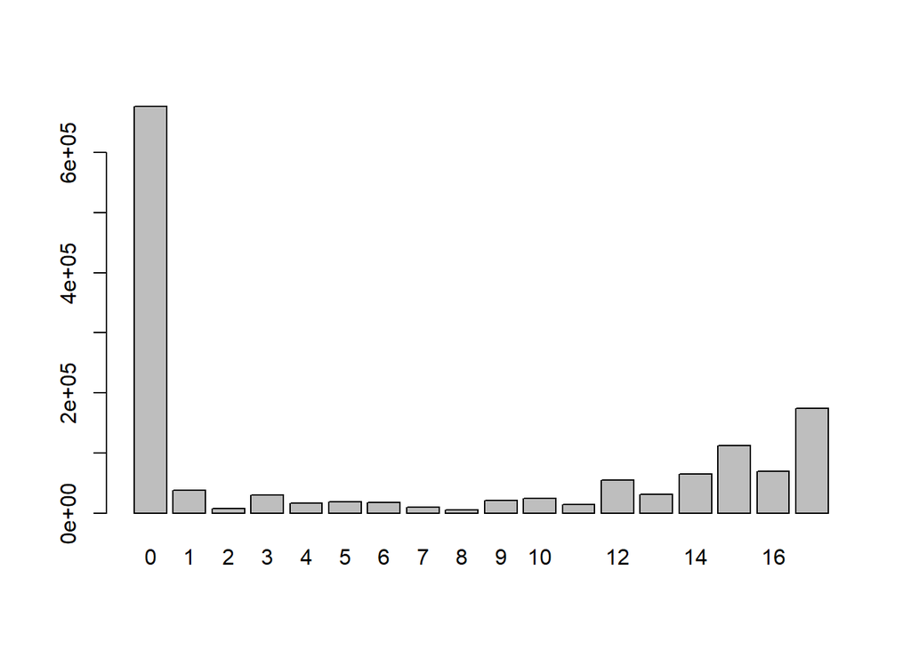

```r
barplot(tapply(gasto_total_faixa_etaria$CustoInternaçao,
               gasto_total_faixa_etaria$Idade,
               FUN = sum))
```

A faixa etária que possui o maior gasto total é entre 0 e 1 ano

### Pergunta 3: Qual grupo baseado em diagnóstico (Aprdrg) tem o maior gasto total no hospital?

Podemos mais uma vez usar a função aggregate.

```r
gasto_total_grupo = aggregate(data = dados,
                                     CustoInternaçao ~ GrupoDiagnosticoRefinado,
                                     FUN = sum)

gasto_total_grupo[which.max(gasto_total_grupo$CustoInternaçao),]
```

```
##    GrupoDiagnosticoRefinado CustoInternaçao
## 44                      640          436822
```

O grupo que possui o maior gasto é o 640

### Pergunta 4: A raça do paciente tem relação com o total gasto em internações no hospital?

Vamos usar o teste ANOVA

Variável dependente: CustoInternaçao

Variável independente: Raça

Hipóteses:

H0 - A variável Raça não afeta a variável CustoInternação

H1 - A variável Raça afeta a variável CustoInternação

```r
teste_anova = aov(CustoInternaçao ~ Raça, data = dados)
summary(teste_anova)
```

```
##              Df    Sum Sq  Mean Sq F value Pr(>F)
## Raça          5 1.859e+07  3718656   0.244  0.943
## Residuals   493 7.524e+09 15260687
```

Conclusão:

Valor-p > 0.05, logo, falhamos em rejeitar a H0.

A raça do paciente não influencia no total gasto com internações no hospital

### Pergunta 5: A combinação de idade e gênero dos pacientes influencia no gasto total em internações no hospital?

Vamos usar o teste ANOVA mais uma vez

Variável dependente: CustoInternaçao

Variáveis independentes: Idade, Sexo

Hipóteses:

H0 - As variáveis Idade e Sexo não afetam a variável CustoInternação

H1 - As variáves Idade e Sexo afetam a variável CustoInternação

```r
teste_anova_2 = aov(CustoInternaçao ~ Idade + Sexo, data = dados)
summary(teste_anova_2)
```

```
##              Df    Sum Sq   Mean Sq F value  Pr(>F)
## Idade         1 1.297e+08 129749266   8.759 0.00323 **
## Sexo          1 6.522e+07  65219972   4.403 0.03638 *
## Residuals   496 7.347e+09  14812787
## ---
## Signif. codes:  0 '***' 0.001 '**' 0.01 '*' 0.05 '.' 0.1 ' ' 1
```

Conclusão:

Valor-p < 0.05 para as duas variáveis independentes, logo, rejeitamos a H0.

### Pergunta 6: Como o tempo de permanência é o fator crucial para pacientes internados, desejamos descobrir se o tempo de permanência pode ser previsto a partir de idade, gênero e raça.

Faremos a previsão com um modelo de Regressão Linear

Variável dependente: TempoInternaçao

Variáveis independentes: Idade, Sexo, Raça

H0 - Não há relação linear entre as variáveis dependente e independentes

H1 - Há relação linear entre as variáveis dependente e independentes

```r
modelo = lm(TempoInternaçao ~ Idade + Sexo + Raça, data = dados)
summary(modelo)
```

```
##
## Call:
## lm(formula = TempoInternaçao ~ Idade + Sexo + Raça, data = dados)
##
## Residuals:
##    Min     1Q Median     3Q    Max
## -3.211 -1.211 -0.857  0.143 37.789
##
## Coefficients:
##             Estimate Std. Error t value Pr(>|t|)
## (Intercept)  2.85687    0.23160  12.335   <2e-16 ***
## Idade       -0.03938    0.02258  -1.744   0.0818 .
## Sexo1        0.35391    0.31292   1.131   0.2586
## Raça2       -0.37501    1.39568  -0.269   0.7883
## Raça3        0.78922    3.38581   0.233   0.8158
## Raça4        0.59493    1.95716   0.304   0.7613
## Raça5       -0.85687    1.96273  -0.437   0.6626
## Raça6       -0.71879    2.39295  -0.300   0.7640
## ---
## Signif. codes:  0 '***' 0.001 '**' 0.01 '*' 0.05 '.' 0.1 ' ' 1
##
## Residual standard error: 3.376 on 491 degrees of freedom
## Multiple R-squared:  0.008699,   Adjusted R-squared:  -0.005433
## F-statistic: 0.6156 on 7 and 491 DF,  p-value: 0.7432
```

Conclusão:

Valor-p > 0.05 para todas as variáveis independentes, logo, falhamos em rejeitar a H0

O tempo de permanência não pode ser previsto a partir da idade, gênero e raça.

### Pergunta 7

Quais variáveis têm maior impacto nos custos de internação hospitalar?

Faremos a previsão com um modelo de Regressão Linear novamente

Variável dependente: CustoInternaçao

Variáveis independentes: Idade, Sexo, Raça, TempoInternaçao, GrupoDiagnosticoRefinado

H0 - Não há relação linear entre as variáveis dependente e independentes

H1 - Há relação linear entre as variáveis dependente e independentes

```r
modelo_v2 = lm(CustoInternaçao ~ ., data = dados)
summary(modelo_v2)
```

```
##
## Call:
## lm(formula = CustoInternaçao ~ ., data = dados)
##
## Residuals:
##    Min     1Q Median     3Q    Max
##  -6367   -691   -186    121  43412
##
## Coefficients:
##                            Estimate Std. Error t value Pr(>|t|)
## (Intercept)               5024.9610   440.1366  11.417  < 2e-16 ***
## Idade                      133.2207    17.6662   7.541 2.29e-13 ***
## Sexo1                     -392.5778   249.2981  -1.575    0.116
## TempoInternaçao            742.9637    35.0464  21.199  < 2e-16 ***
## Raça2                      458.2427  1085.2320   0.422    0.673
## Raça3                      330.5184  2629.5121   0.126    0.900
## Raça4                     -499.3818  1520.9293  -0.328    0.743
## Raça5                    -1784.5776  1532.0048  -1.165    0.245
## Raça6                     -594.2921  1859.1271  -0.320    0.749
## GrupoDiagnosticoRefinado    -7.8175     0.6881 -11.361  < 2e-16 ***
## ---
## Signif. codes:  0 '***' 0.001 '**' 0.01 '*' 0.05 '.' 0.1 ' ' 1
##
## Residual standard error: 2622 on 489 degrees of freedom
## Multiple R-squared:  0.5544, Adjusted R-squared:  0.5462
## F-statistic:  67.6 on 9 and 489 DF,  p-value: < 2.2e-16
```

As variáveis que possuem o maior impacto no custo de internação hospitalar são as variáveis Idade, TempoInternaçao e GrupoDiagnosticoRefinado.

Vemos também que a variável Raça não é significativa.

Vamos removê-la e construir um novo modelo.

```r
modelo_v3 = lm(CustoInternaçao ~ Idade + Sexo + TempoInternaçao + GrupoDiagnosticoRefinado, data = dados)
summary(modelo_v3)
```

```
##
## Call:
## lm(formula = CustoInternaçao ~ Idade + Sexo + TempoInternaçao +
##     GrupoDiagnosticoRefinado, data = dados)
##
## Residuals:
##    Min     1Q Median     3Q    Max
##  -6344   -687   -168    132  43387
##
## Coefficients:
##                          Estimate Std. Error t value Pr(>|t|)
## (Intercept)              4971.980    433.116  11.480  < 2e-16 ***
## Idade                     134.241     17.462   7.688 8.16e-14 ***
## Sexo1                    -383.082    247.571  -1.547    0.122
## TempoInternaçao           743.618     34.914  21.298  < 2e-16 ***
## GrupoDiagnosticoRefinado   -7.767      0.681 -11.405  < 2e-16 ***
## ---
## Signif. codes:  0 '***' 0.001 '**' 0.01 '*' 0.05 '.' 0.1 ' ' 1
##
## Residual standard error: 2613 on 494 degrees of freedom
## Multiple R-squared:  0.5528, Adjusted R-squared:  0.5492
## F-statistic: 152.7 on 4 and 494 DF,  p-value: < 2.2e-16
```

A variável Sexo não possui grande significância estatística. Vamos removê-la e construir um novo modelo.

```r
modelo_v4 = lm(CustoInternaçao ~ Idade + TempoInternaçao + GrupoDiagnosticoRefinado, data = dados)
summary(modelo_v4)
```

```
##
## Call:
## lm(formula = CustoInternaçao ~ Idade + TempoInternaçao + GrupoDiagnosticoRefinado,
##     data = dados)
##
## Residuals:
##    Min     1Q Median     3Q    Max
##  -6603   -719   -169    124  43350
##
## Coefficients:
##                           Estimate Std. Error t value Pr(>|t|)
## (Intercept)              4960.1705   433.6579   11.44  < 2e-16 ***
## Idade                     128.5519    17.0946    7.52 2.59e-13 ***
## TempoInternaçao           740.8057    34.9161   21.22  < 2e-16 ***
## GrupoDiagnosticoRefinado   -8.0055     0.6643  -12.05  < 2e-16 ***
## ---
## Signif. codes:  0 '***' 0.001 '**' 0.01 '*' 0.05 '.' 0.1 ' ' 1
##
## Residual standard error: 2617 on 495 degrees of freedom
## Multiple R-squared:  0.5506, Adjusted R-squared:  0.5479
## F-statistic: 202.2 on 3 and 495 DF,  p-value: < 2.2e-16
```

Agora temos um modelo com todas as variáveis com alta significância. Porém, a variavel GrupoDiagnosticoRefinado possui valor t negativo.

```r
summary(modelo_v4)
```

```
##
## Call:
## lm(formula = CustoInternaçao ~ Idade + TempoInternaçao + GrupoDiagnosticoRefinado,
##     data = dados)
##
## Residuals:
##    Min     1Q Median     3Q    Max
##  -6603   -719   -169    124  43350
##
## Coefficients:
##                           Estimate Std. Error t value Pr(>|t|)
## (Intercept)              4960.1705   433.6579   11.44  < 2e-16 ***
## Idade                     128.5519    17.0946    7.52 2.59e-13 ***
## TempoInternaçao           740.8057    34.9161   21.22  < 2e-16 ***
## GrupoDiagnosticoRefinado   -8.0055     0.6643  -12.05  < 2e-16 ***
## ---
## Signif. codes:  0 '***' 0.001 '**' 0.01 '*' 0.05 '.' 0.1 ' ' 1
##
## Residual standard error: 2617 on 495 degrees of freedom
## Multiple R-squared:  0.5506, Adjusted R-squared:  0.5479
## F-statistic: 202.2 on 3 and 495 DF,  p-value: < 2.2e-16
```

As variáveis que possuem o maior impacto no custo de internação hospitalar são as variáveis Idade, TempoInternaçao e GrupoDiagnosticoRefinado.